# 技工&普工招聘和薪酬水平

## 总述

本次采集有效数据4560条，主要分析技工&普工的招聘和薪酬水平，我们将从如下方面分析：

- 城市分布：深圳占13%，平均月薪6327元；广州占10%，平均月薪5680元；上海占7%，平均月薪6357元；武汉占7%，平均月薪5592元；苏州占7%，平均月薪6777元；其余城市均在6%或以下。
- 行业分布：电子技术/半导体/集成电路占13%，平均月薪6049元；机械/设备/重工占17%，平均月薪6553元；原材料和加工占7%，平均月薪6313元；其余行业均在5%或以下。
- 公司规模：1000人以下占86%，平均月薪6066元；1000-5000人占11%，平均月薪6437元；5000人以上占3%，平均月薪6151元。
- 公司类型：民营占70%，平均月薪6108元；外企占13%，平均月薪6053元
- 工作经验：5年以下占98%，平均月薪6086元；5-10年占1.6%，平均月薪7555元。
- 学历要求：中专/中技占60%，平均月薪6101元；初中及以下占19%，平均月薪5891元；高中占16%，平均月薪6267元。
- 细分岗位：普工平均月薪5693元；技工平均月薪6526元。

## 01.城市分布

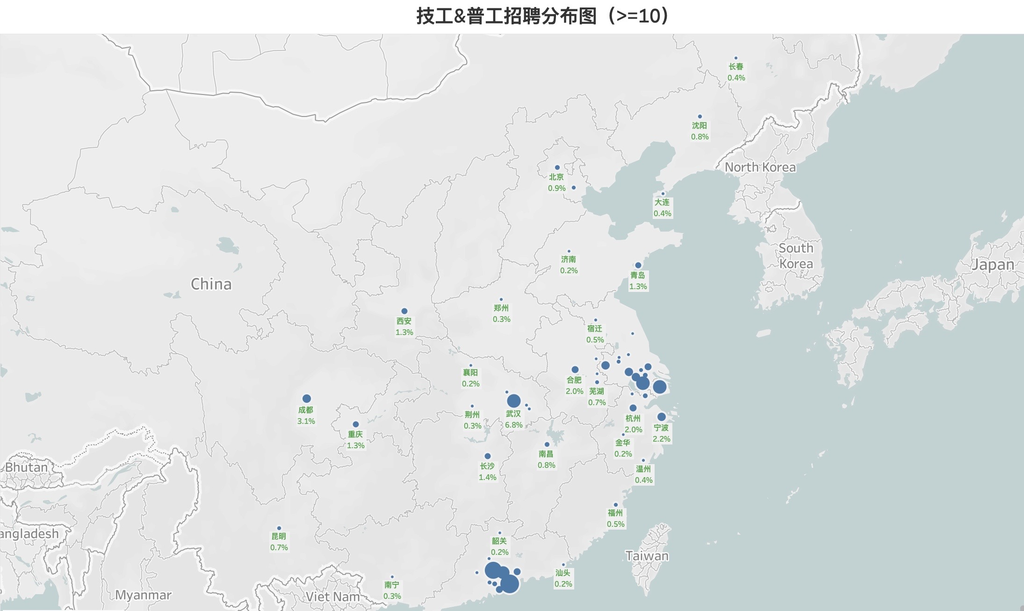

roadmap

## 02.行业分布

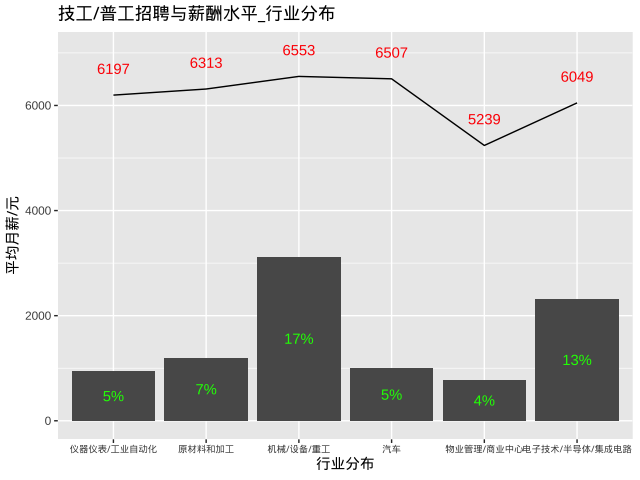

industries

## 03.公司规模

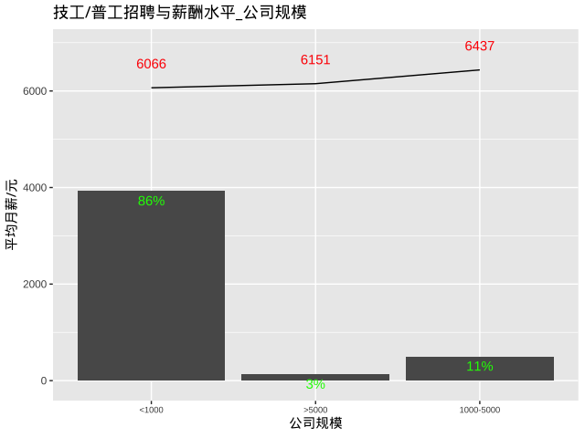

com_size

## 04.公司类型

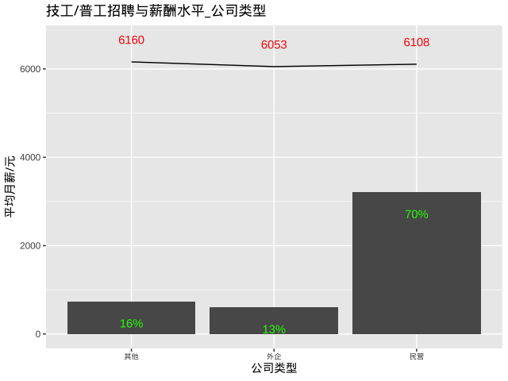

com_type

## 05.工作经验

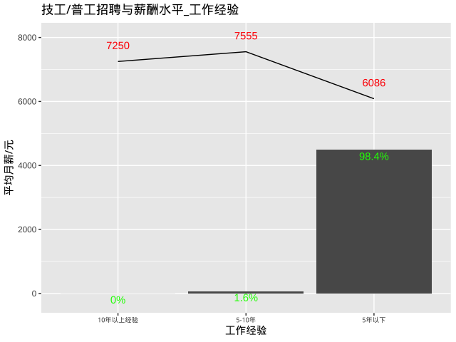

experience

## 06.学历要求

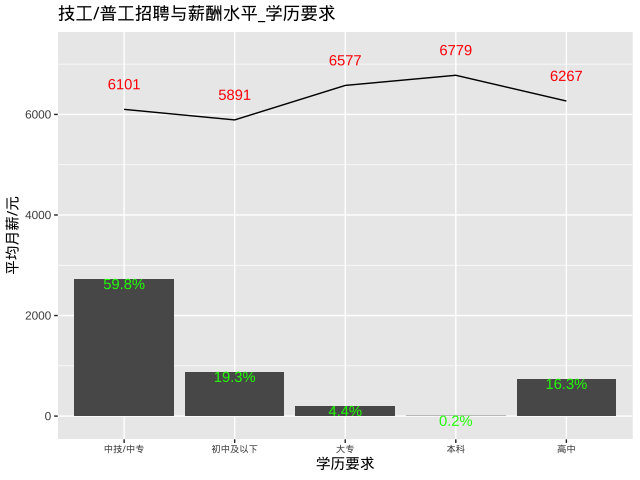

education

## 07.细分岗位

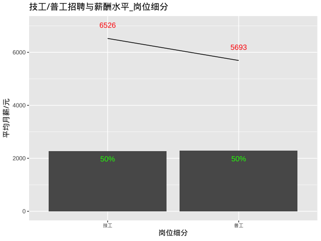

subclass